# Lecture 29

Tim Hagemeister

4 December 2019

## Last Topic: T-test

Recall CLT: As sample size increases, our common sampel statistics (like xbar and phat) follow normal distributions.

- Past 3 weeks: all about phat and p (proportion) for categorical data
- Now: Same thing but with numerical/quantitative data, in particular: **means!!!**

The Central limit theorom works for xbar just liek it does for phat: if n is large, then xbar follows a normal distribution with:

- center = $\mu$ (mu)
- SE = $sigma/\sqrt{(n)}$

All together, we can make CIs and hyp tests.

## CIs for mu

Same format as always: (point est) +/- (crit val)*SE

Here: $\bar{x} (+/-) (crit val)*sigma/\sqrt(n)$

## Hyp Test

Same format as always: z = (obs - exp) / (SE)

Here: z = $(\bar{x} - mu)/(sigma/\sqrt{n})$

## One problem: whats sigma

Recall, statistical inference is the process of making conclusions about our populations based upon our sample results.

In other words, we dont know what i s going on with the population!! we are trying to figure that out

So, if we dont know mu, how on earth do we know sigma

Solution: use s instead, since of course we do have the sample std dev.

## one more problem: not quite normal

When we swap out sigma for S, the rstult is not quite normal, instead, it follows a very similar distribution: the t distribution

thee idea is: without sigma, we have less info about the population. we have to pay for it. That price is the t distribution.

T distribution looks just like normal, but shorter with fatter tails

This has two important effects:

- Wider CIs (bummer!) I.e. bigger margin of error (bummer!)
- p-vals are bigger with the t (bummer!)

Bummer! but, its how we “pay” for not knwoing sigma.

## Degrees of freedom

T dists depend on sample size. Bigger n means closer to z (normal), which makes sense since larger n means more infor about the population

for n >100 virtually no difference between t and z.

```r
t.values <- seq(-4,4,.1)
expression(infinity)
```

```
## expression(infinity)
```

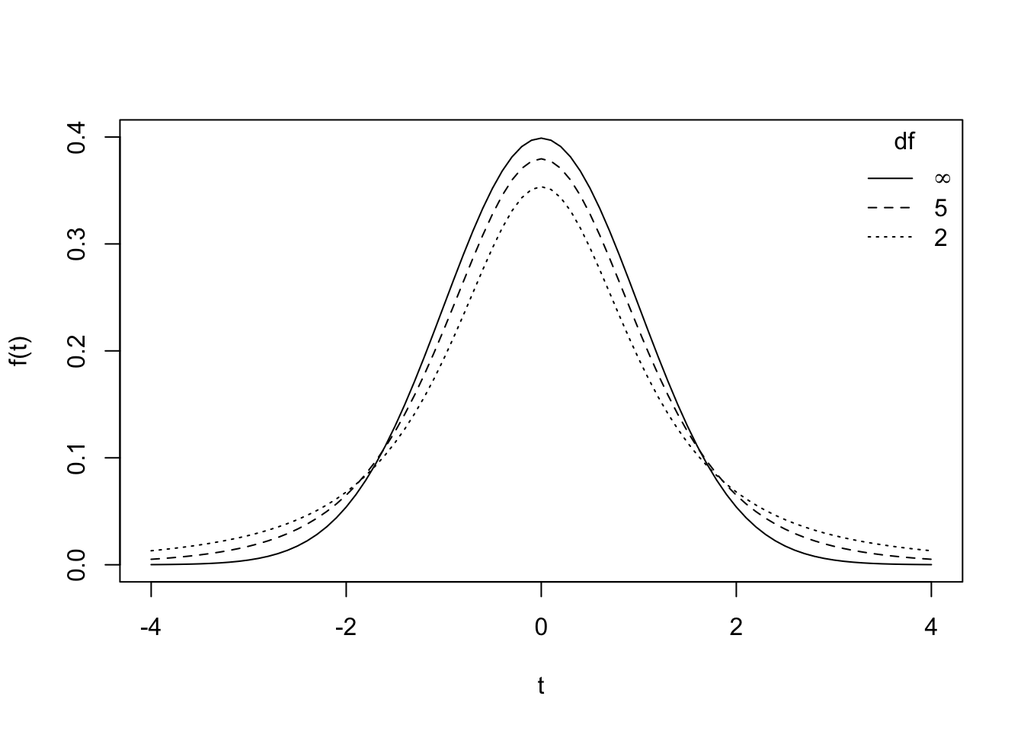

```r
plot(x = t.values,y = dt(t.values,2), type = "l", lty = "dotted", ylim = c(0,.4), xlab = "t", ylab = "f(t)")

lines(t.values,dt(t.values,5),lty = "dashed")

lines(t.values,dnorm(t.values))

legend("topright", title = "df",legend =
c(expression(infinity),"5","2"), lty =
c("solid","dashed","dotted"), bty = "n")
```

Format :

xbar +/- crit val * s/sqrt(n)

xbar = 66 s = 4.1 n = 23

So whats crit val?

Recall for z, how did we find 1.96

```r
qnorm(.025)
```

```
## [1] -1.959964
```

Here same thing, but use QT isntead of qnorm

**T distribtuino depends on sample size**

```r
qt(.025, 23-1) # note: 23 - 1 is the df (degrees of freedom )
```

```
## [1] -2.073873
```

```r
66- 2.074*4.1/sqrt(23)
```

```
## [1] 64.22692
```

```r
66+ 2.074*4.1/sqrt(23)
```

```
## [1] 67.77308
```

Based upon this sample, we are 95% confident that the treu mean height of DU Students is between 64.2 inches and 67.8 inches tall.

## Example

Suppose a sample of 31 giraffes is taken, and their avg height is computed to be 17.7 feet tall with std dev 2.9 ft. based upon this sample, estiamte the mean height of all giraffes with 90% Confidence.

- xbar = 17.7
- s = 2.9
- n = 31

```r
qt(.05, 31-1) # note: 31 - 1 is the df (degrees of freedom = (n-1) )
```

```
## [1] -1.697261
```

```r
17.7- 1.7*2.9/sqrt(31)
```

```
## [1] 16.81455
```

```r
17.7+ 1.7*2.9/sqrt(31)
```

```
## [1] 18.58545
```

Based upon this sampel, we can estimate with a 90% confidence that the true mean height of all giraffes would be between 16.81 and 18.59 feet tall.